# Human Resources Analysis

Daniel Herranz

6 de marzo de 2017

In this exercise is trying to understand why the employees of a company are leaving and predict will be next.

The report are split in the following steps:

1- Read and clean the data.

2- Exploratory data analysis.

3- Machine learning.

# 1- READ THE DATA.

### Take a look to data set

```
## 'data.frame':    14999 obs. of  10 variables:
##  $ satisfaction_level   : num  0.38 0.8 0.11 0.72 0.37 0.41 0.1 0.92 0.89 0.42 ...
##  $ last_evaluation      : num  0.53 0.86 0.88 0.87 0.52 0.5 0.77 0.85 1 0.53 ...
##  $ number_project       : int  2 5 7 5 2 2 6 5 5 2 ...
##  $ average_montly_hours : int  157 262 272 223 159 153 247 259 224 142 ...
##  $ time_spend_company   : int  3 6 4 5 3 3 4 5 5 3 ...
##  $ Work_accident        : int  0 0 0 0 0 0 0 0 0 0 ...
##  $ left                 : int  1 1 1 1 1 1 1 1 1 1 ...
##  $ promotion_last_5years: int  0 0 0 0 0 0 0 0 0 0 ...
##  $ sales                : Factor w/ 10 levels "accounting","hr",..: 8 8 8 8 8 8 8 8 8 8 ...
##  $ salary               : Factor w/ 3 levels "high","low","medium": 2 3 3 2 2 2 2 2 2 2 ...
```

### Review the format of variables.

### Review NULL values.

```
##    satisfaction_level       last_evaluation        number_project
##                     0                     0                     0
##  average_montly_hours    time_spend_company         Work_accident
##                     0                     0                     0
##                  left promotion_last_5years            department
##                     0                     0                     0
##                salary
##                     0
```

# 2- Exploratory data analysis.

## Preview header

```
##   satisfaction_level last_evaluation number_project average_montly_hours
## 1               0.38            0.53              2                  157
## 2               0.80            0.86              5                  262
## 3               0.11            0.88              7                  272
## 4               0.72            0.87              5                  223
## 5               0.37            0.52              2                  159
## 6               0.41            0.50              2                  153
##   time_spend_company Work_accident     left promotion_last_5years
## 1                  3   NO_ACCIDENT YES_LEFT          NO_PROMOTION
## 2                  6   NO_ACCIDENT YES_LEFT          NO_PROMOTION
## 3                  4   NO_ACCIDENT YES_LEFT          NO_PROMOTION
## 4                  5   NO_ACCIDENT YES_LEFT          NO_PROMOTION
## 5                  3   NO_ACCIDENT YES_LEFT          NO_PROMOTION
## 6                  3   NO_ACCIDENT YES_LEFT          NO_PROMOTION
##   department salary
## 1      sales    low
## 2      sales medium
## 3      sales medium
## 4      sales    low
## 5      sales    low
## 6      sales    low
```

## Review type of data, dispersion analysis, count of cathegorical

```
##  satisfaction_level last_evaluation  number_project  average_montly_hours
##  Min.   :0.0900     Min.   :0.3600   Min.   :2.000   Min.   : 96.0
##  1st Qu.:0.4400     1st Qu.:0.5600   1st Qu.:3.000   1st Qu.:156.0
##  Median :0.6400     Median :0.7200   Median :4.000   Median :200.0
##  Mean   :0.6128     Mean   :0.7161   Mean   :3.803   Mean   :201.1
##  3rd Qu.:0.8200     3rd Qu.:0.8700   3rd Qu.:5.000   3rd Qu.:245.0
##  Max.   :1.0000     Max.   :1.0000   Max.   :7.000   Max.   :310.0
##
##  time_spend_company      Work_accident         left
##  Min.   : 2.000     NO_ACCIDENT :12830   NO_LEFT :11428
##  1st Qu.: 3.000     YES_ACCIDENT: 2169   YES_LEFT: 3571
##  Median : 3.000
##  Mean   : 3.498
##  3rd Qu.: 4.000
##  Max.   :10.000
##
##    promotion_last_5years       department      salary
##  NO_PROMOTION :14680     sales      :4140   high  :1237
##  YES_PROMOTION:  319     technical  :2720   low   :7316
##                          support    :2229   medium:6446
##                          IT         :1227
##                          product_mng: 902
##                          marketing  : 858
##                          (Other)    :2923
```

## The data set is formed by the following values:

- Employee satisfaction level (satisfaction_level)
- Last evaluation (last_evaluation)
- Number of projects (number_project)
- Average monthly hours (average_montly_hours)
- Time spent at the company (time_spend_company)
- Whether they have had a work accident (Work_accident)
- Whether they have had a promotion in the last 5 years (promotion_last_5years)
- Sales (sales)
- Salary (salary)
- Whether the employee has left (left)

## 2.1 - First look of the data

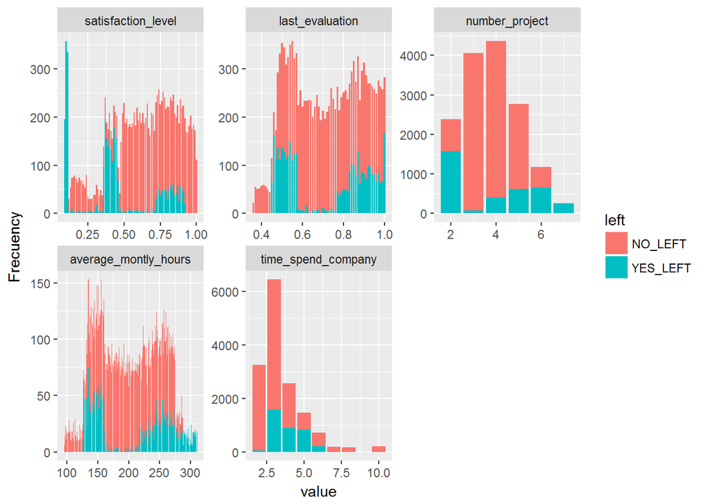

[figure not shown]

## 2.2 -How many employees left the company?

### Total of employees left the company

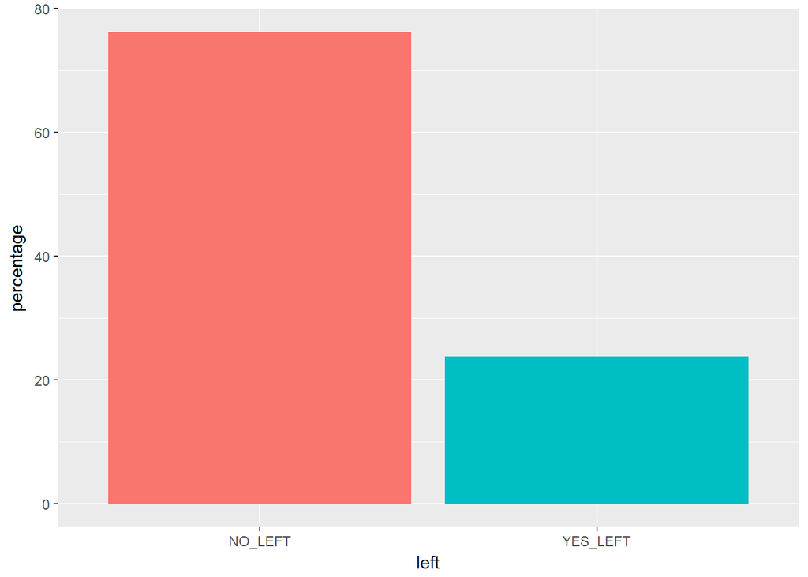

23,85% employees leaves the company.

### Total of employees left the company by department

```
## # A tibble: 10 × 3
##     department total     ratio
##         <fctr> <int>     <dbl>
## 1   accounting   204  5.712686
## 2           hr   215  6.020722
## 3           IT   273  7.644917
## 4   management    91  2.548306
## 5    marketing   203  5.684682
## 6  product_mng   198  5.544665
## 7        RandD   121  3.388407
## 8        sales  1014 28.395407
## 9      support   555 15.541865
## 10   technical   697 19.518342
```

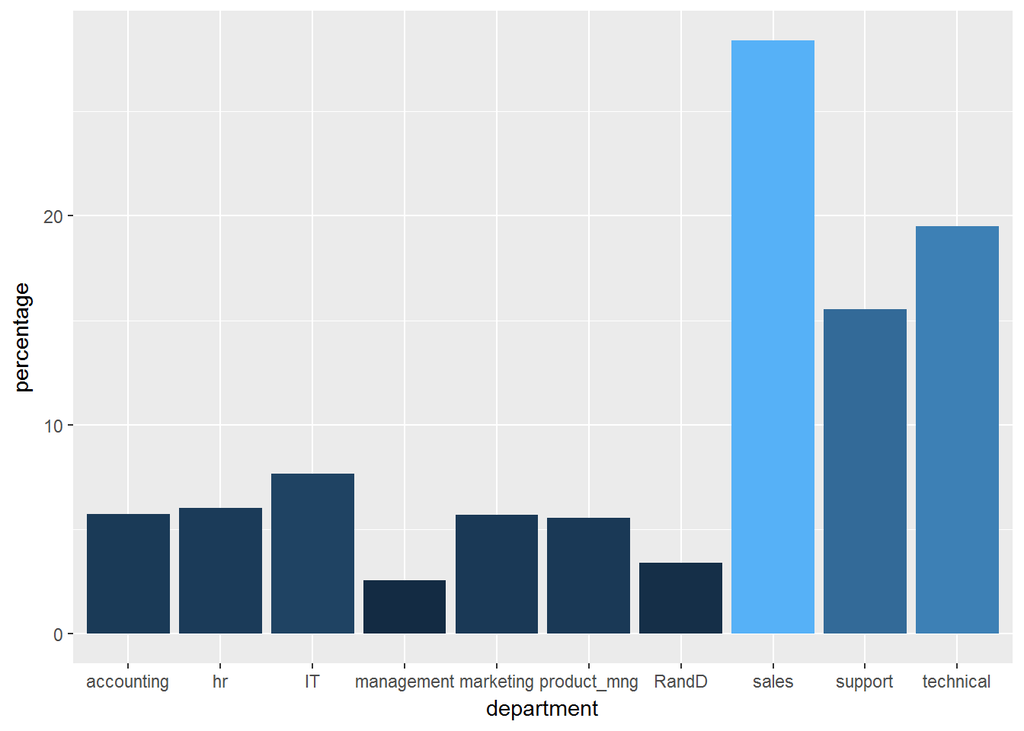

It is in sale, support and technical departments whith highest leave ratio

## 2.4 -Why employees leave the company?

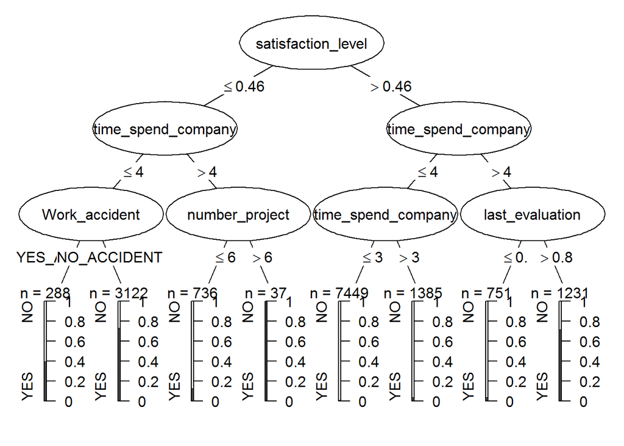

Satisfaccion level and time spend company are the more relevant values to determine if an employee leave or not the company.

# 3- Machine learning.

## 3.1 - Split the data into training and testing .

```
##
##   NO  YES
## 8000 2500
```

```
##
##   NO  YES
## 3428 1071
```

# 3.2 - Using random forest to predict

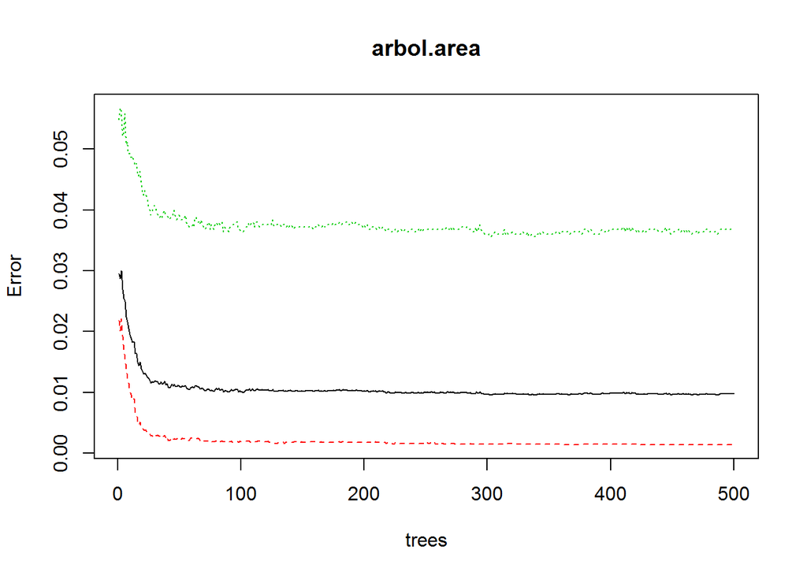

Dotchart of variable importance

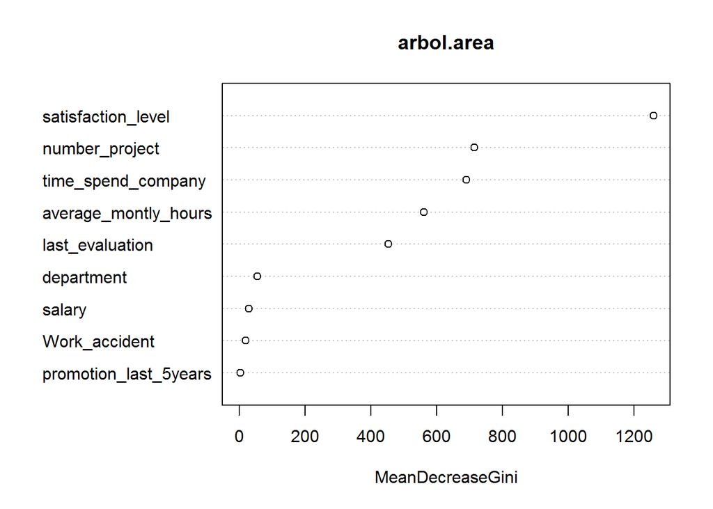

# 3.3 - Analyse the result of performing algorithm

## Confustion matrix

Also known as an error matrix, is a specific table layout that allows visualization of the performance of an algorithm, typically a supervised learning one (in unsupervised learning it is usually called a matching matrix). Each column of the matrix represents the instances in a predicted class while each row represents the instances in an actual class (or vice versa). The name stems from the fact that it makes it easy to see if the system is confusing two classes (i.e. commonly mislabelling one as another).

https://en.wikipedia.org/wiki/Confusion_matrix

```
## Confusion Matrix and Statistics
##
##           Reference
## Prediction   NO  YES
##        NO  3421   43
##        YES    7 1028
##
##                Accuracy : 0.9889
##                  95% CI : (0.9854, 0.9917)
##     No Information Rate : 0.7619
##     P-Value [Acc > NIR] : < 2.2e-16
##
##                   Kappa : 0.969
##  Mcnemar's Test P-Value : 7.431e-07
##
##             Sensitivity : 0.9980
##             Specificity : 0.9599
##          Pos Pred Value : 0.9876
##          Neg Pred Value : 0.9932
##              Prevalence : 0.7619
##          Detection Rate : 0.7604
##    Detection Prevalence : 0.7699
##       Balanced Accuracy : 0.9789
##
##        'Positive' Class : NO
##
```

The meaning of the principal ratios are:

#### Sensitivity

The chance of testing positive among those with the condition The chance of rejecting the null hypothesis among those that do not satisfy the null hypothesis 1 - Type II Error TP / (TP + FN) = n11 / (n10 + n11)

#### Specificity or Selectivity

The chance of testing negative among those without the condition The chance of accepting the null hypothesis among those that satisfy the null hypothesis 1 - Type I Error TN / (TN + FP) = n00 / (n00 + n01)

#### Positive Predictive Value

The chance of having the condition among those that test positive The chance of not satisfying the null hypothesis among those that reject the null hypothesis 1 - False Discovery Rate TP / (TP + FP) = n11 / (n01 + n11)

#### Negative Predictive Value

The chance of not having the condition among those that test negative The chance of satisfying the null hypothesis among those that accept the null hypothesis 1 - False Omission Rate TN / (TN + FN) = n00 / (n00 + n10)

# ROC curve

In statistics, a receiver operating characteristic curve, or ROC curve, is a graphical plot that illustrates the performance of a binary classifier system as its discrimination threshold is varied. The curve is created by plotting the true positive rate (TPR) against the false positive rate (FPR) at various threshold settings. The true-positive rate is also known as sensitivity, recall or probability of detection[1] in machine learning. The false-positive rate is also known as the fall-out or probability of false alarm[1] and can be calculated as (1 − specificity). The ROC curve is thus the sensitivity as a function of fall-out. In general, if the probability distributions for both detection and false alarm are known, the ROC curve can be generated by plotting the cumulative distribution function (area under the probability distribution from {-} -to the discrimination threshold) of the detection probability in the y-axis versus the cumulative distribution function of the false-alarm probability in x-axis.

ROC analysis provides tools to select possibly optimal models and to discard suboptimal ones independently from (and prior to specifying) the cost context or the class distribution. ROC analysis is related in a direct and natural way to cost/benefit analysis of diagnostic decision making.

https://en.wikipedia.org/wiki/Receiver_operating_characteristic

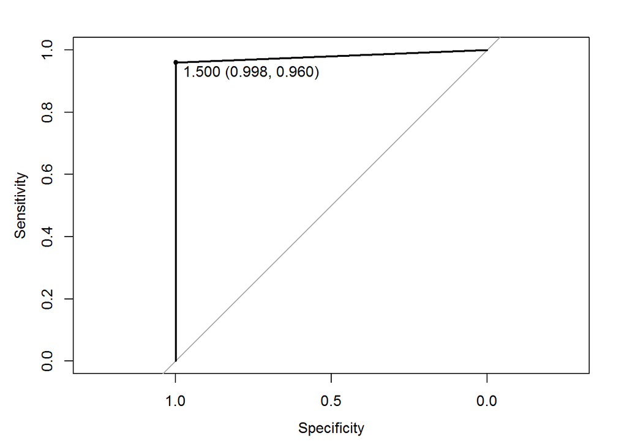